# Лабораторна робота № 6

# ЧАСТИНА 2. Інтерпретація моделі

Перша частина дала **число**. Друга має дати **пояснення**: чому модель вважає конкретного клієнта ризиковим, і чи можна на цьому пояснення будувати дії відділу утримання.

Головна думка цієї частини: **кожен із трьох інструментів пояснення має власний спосіб збрехати**, і ви маєте вміти ці випадки впізнавати.

Далі працюємо з однією навченою моделлю. Зафіксуємо її зараз.

```python
FINAL_X = X5                      # з якою матрицею працюємо далі
FINAL_CLF = RandomForestClassifier(n_estimators=300, random_state=SEED, n_jobs=-1)

Xtr, Xte, ytr, yte = train_test_split(FINAL_X, y, test_size=0.3,
                                      stratify=y, random_state=SEED)
model = make_pipe(FINAL_X, FINAL_CLF).fit(Xtr, ytr)
auc_hold = roc_auc_score(yte, model.predict_proba(Xte)[:, 1])
print('модель навчена; AUC на відкладеній частині %.3f' % auc_hold)
print('(одне число з широкого розподілу — див. розділ 5.5 конспекту)')
```

```
модель навчена; AUC на відкладеній частині 0.796
(одне число з широкого розподілу — див. розділ 5.5 конспекту)
```

## 9. Важливість ознак: два способи і одна пастка

### Завдання 9.1 — вбудована важливість

`RandomForestClassifier.feature_importances_` рахує, наскільки кожна ознака зменшувала неоднорідність при розбиттях. Виведіть топ-10.

> Увага: після одиничного кодування одна категоріальна ознака перетворюється на кілька стовпців. Щоб порівнювати з вихідними ознаками, важливості дамі-стовпців однієї ознаки треба **підсумувати**.

|  | вбудована |
| --- | --- |
| щомісячний_платіж | 0.110288 |
| вік | 0.106111 |
| трафік_на_Мбіт | 0.092350 |
| трафік_ГБ | 0.063853 |
| місяців_обслуговування | 0.061850 |
| ціна_за_Мбіт | 0.061501 |
| трафік_МБ | 0.061422 |
| дата_підключення | 0.056897 |
| індекс_лояльності_CRM | 0.047149 |
| код_тарифного_плану | 0.039263 |

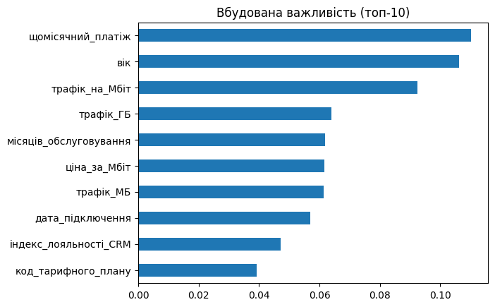

```python
# ----- ВАШ КОД -----
# 1) дістаньте імена після перетворення: model.named_steps['prep'].get_feature_names_out()
prep = model.named_steps['prep']
num_cols = list(prep.transformers_[0][2])
cat_cols = list(prep.transformers_[1][2])
ohe = prep.named_transformers_['cat'].named_steps['ohe']
# 2) підсумуйте важливості дамі-стовпців до вихідних ознак
origin = list(num_cols)
for c, cats in zip(cat_cols, ohe.categories_):
    origin += [c] * len(cats)

imp = model.named_steps['clf'].feature_importances_
assert len(origin) == len(imp), 'кількість колонок не збігається'

gini_imp = (pd.Series(imp, index=origin)
              .groupby(level=0).sum()
              .sort_values(ascending=False))
# 3) побудуйте горизонтальну стовпчикову діаграму топ-10
gini_imp.head(10)[::-1].plot(kind='barh', title='Вбудована важливість (топ-10)');
display(gini_imp.head(10).to_frame('вбудована'))
# gini_imp = None
```

### Завдання 9.2 — перестановочна важливість

Інший підхід: взяти навчену модель, **перемішати значення однієї ознаки** у перевірковій частині й подивитись, наскільки впала якість. Впала сильно — ознака потрібна; не впала — не потрібна.

Рахуйте на **перевірковій** частині: на навчальній перестановочна важливість показує те саме перенавчання, що й вбудована.

```python
perm = permutation_importance(model, Xte, yte, n_repeats=10,
                              random_state=SEED, scoring='roc_auc')
perm_imp = pd.Series(perm.importances_mean, index=FINAL_X.columns).sort_values(ascending=False)
display(perm_imp.head(10).to_frame('перестановочна важливість'))
```

|  | перестановочна важливість |
| --- | --- |
| вік | 0.093431 |
| місяців_обслуговування | 0.025785 |
| щомісячний_платіж | 0.016172 |
| трафік_на_Мбіт | 0.009788 |
| трафік_МБ | 0.009658 |
| трафік_ГБ | 0.008047 |
| кількість_звернень_у_підтримку | 0.006990 |
| автоплатіж | 0.005593 |
| код_тарифного_плану | 0.004950 |
| ціна_за_Мбіт | 0.004050 |